# Alumnos - Nutrición 2014

### Dimensión 2.3 - Proceso enseñanza-aprendizaje

Los resultados de esta dimensión son los siguientes:

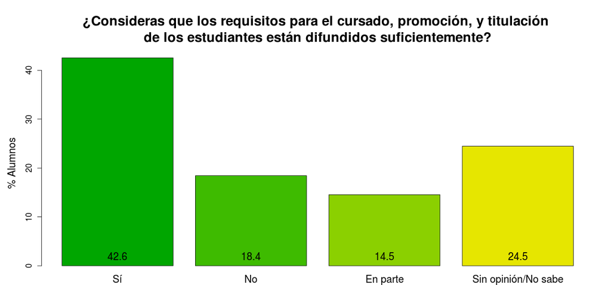

```r
Q.plots(data.alumnos$Q23a, Q23a)
```

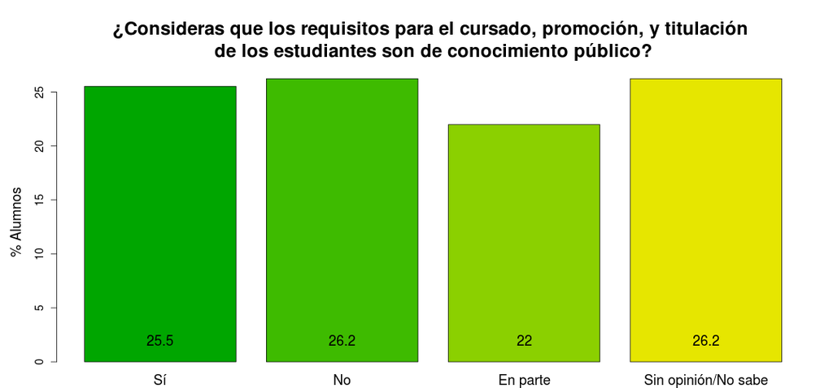

```r
Q.plots(data.alumnos$Q23b, Q23b)
```

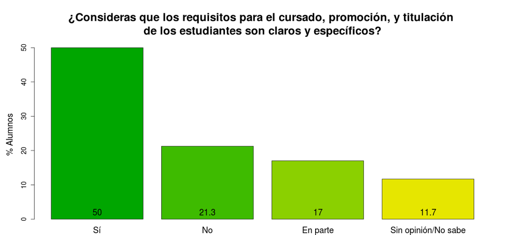

```r
Q.plots(data.alumnos$Q23c, Q23c)
```

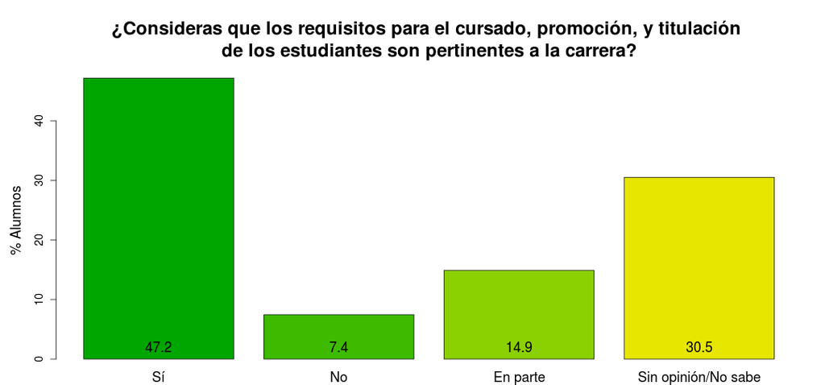

```r
Q.plots(data.alumnos$Q23d, Q23d)
```

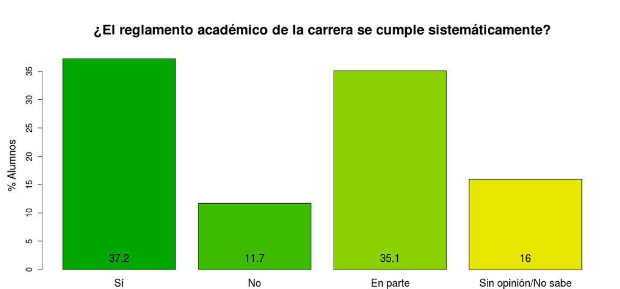

```r
Q.plots(data.alumnos$Q23e, Q23e)
```

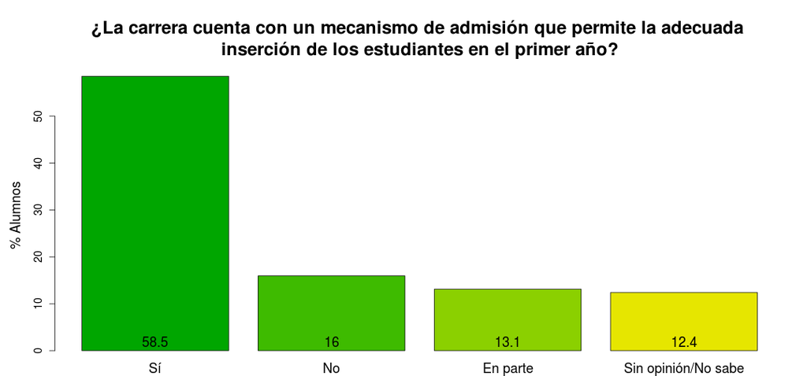

```r
Q.plots(data.alumnos$Q23f, Q23f)
```

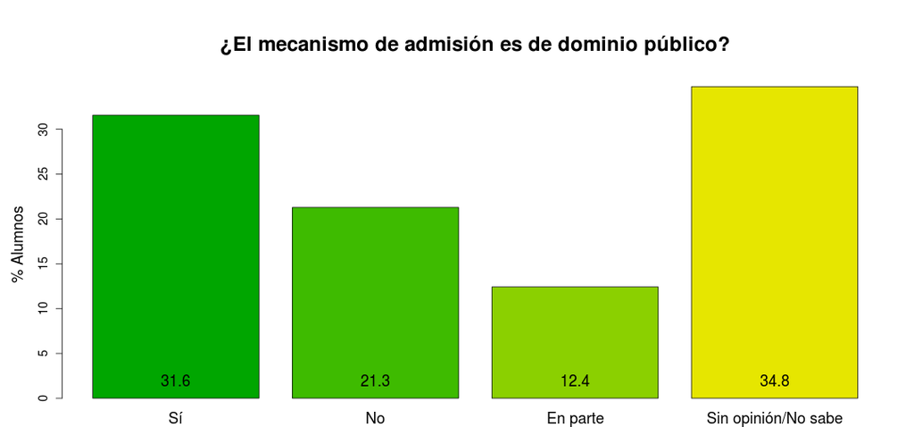

```r
Q.plots(data.alumnos$Q23g, Q23g)
```

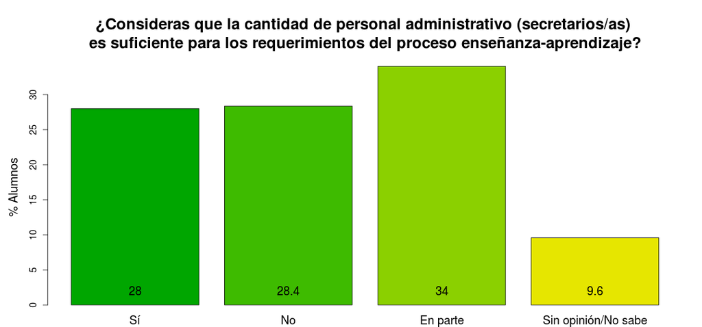

```r
Q.plots(data.alumnos$Q23h, Q23h)
```

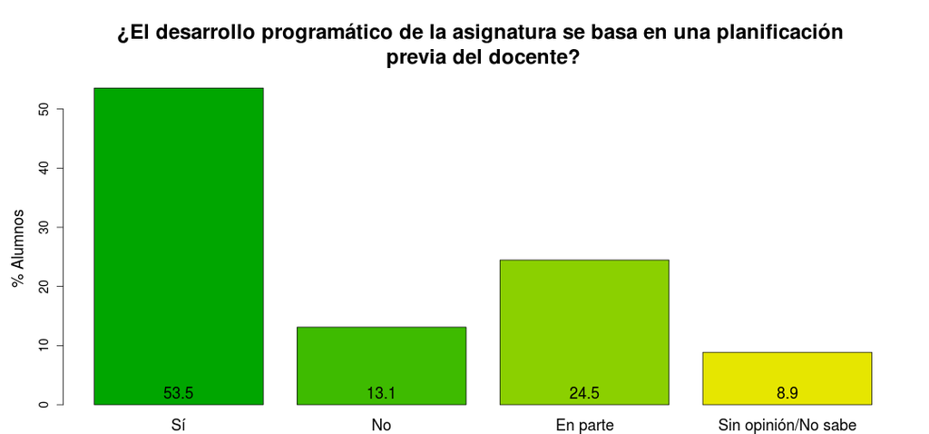

```r
Q.plots(data.alumnos$Q23i, Q23i)
```

### Dimensión 2.4 - Evaluación del proceso enseñanza-aprendizaje

Los resultados de esta dimensión son los siguientes:

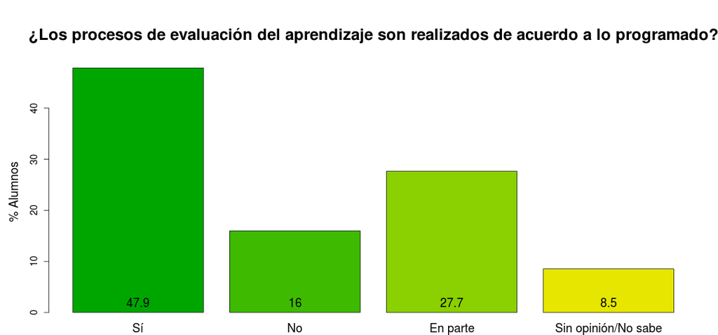

```r
Q.plots(data.alumnos$Q24a, Q24a)
```

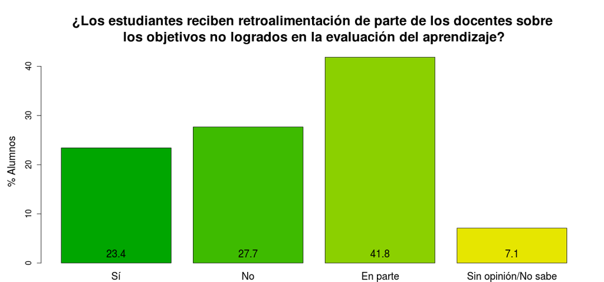

```r
Q.plots(data.alumnos$Q24b, Q24b)
```

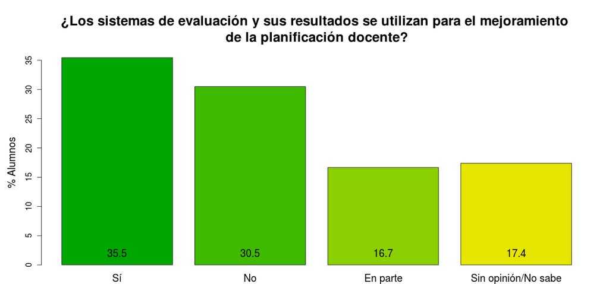

```r
Q.plots(data.alumnos$Q24c, Q24c)
```

### Dimensión 2.5 - Investigación & extensión

Los resultados de esta dimensión son los siguientes:

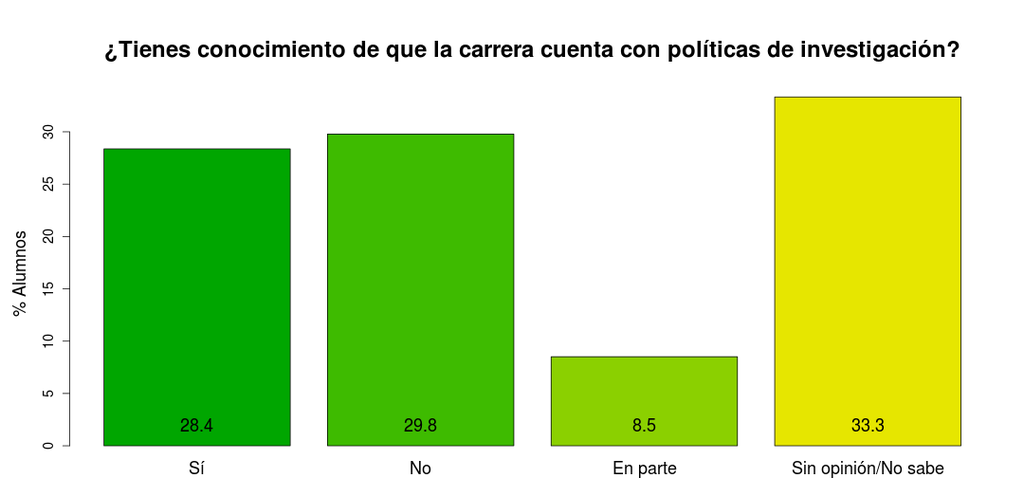

```r
Q.plots(data.alumnos$Q25a, Q25a)
```

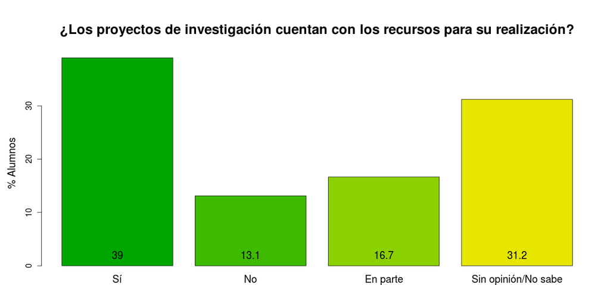

```r
Q.plots(data.alumnos$Q25b, Q25b)
```

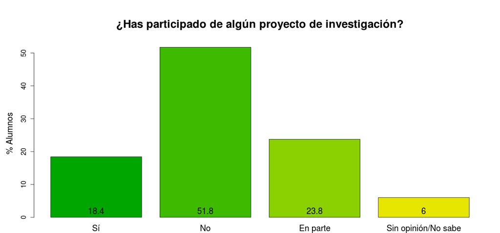

```r
Q.plots(data.alumnos$Q25c, Q25c)
```

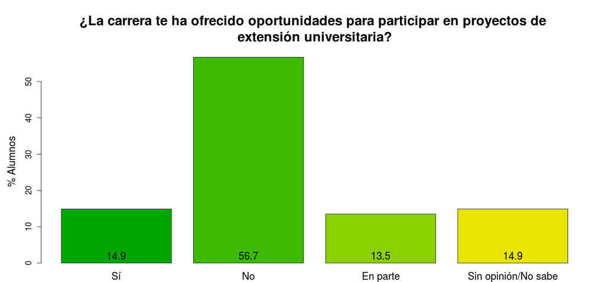

```r
Q.plots(data.alumnos$Q25d, Q25d)
```

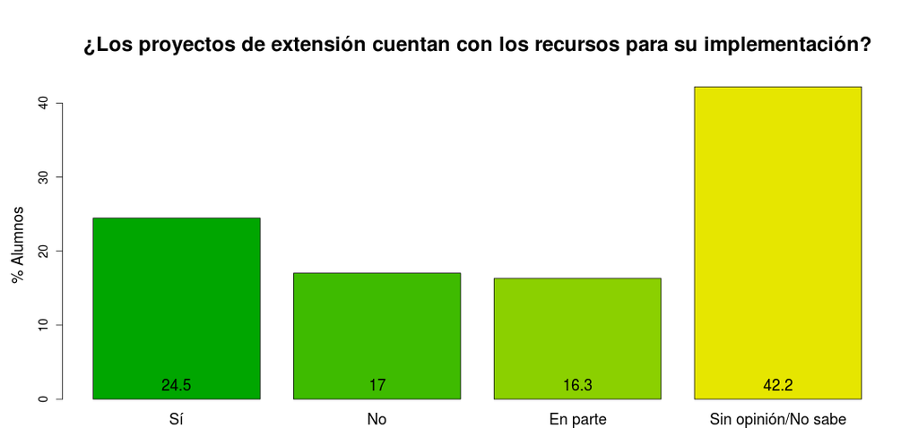

```r
Q.plots(data.alumnos$Q25e, Q25e)
```

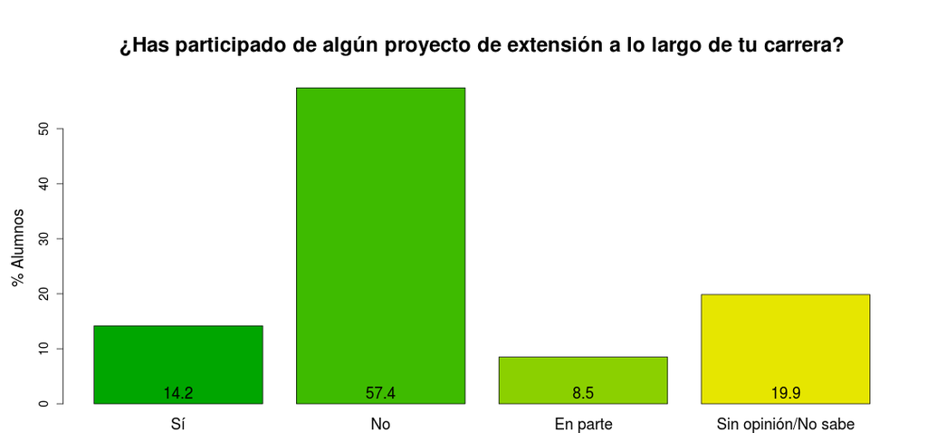

```r
Q.plots(data.alumnos$Q25f, Q25f)
```

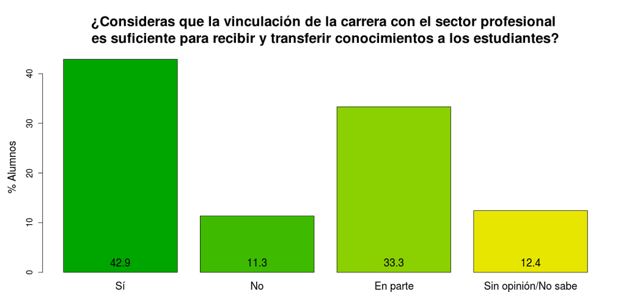

```r
Q.plots(data.alumnos$Q25g, Q25g)
```

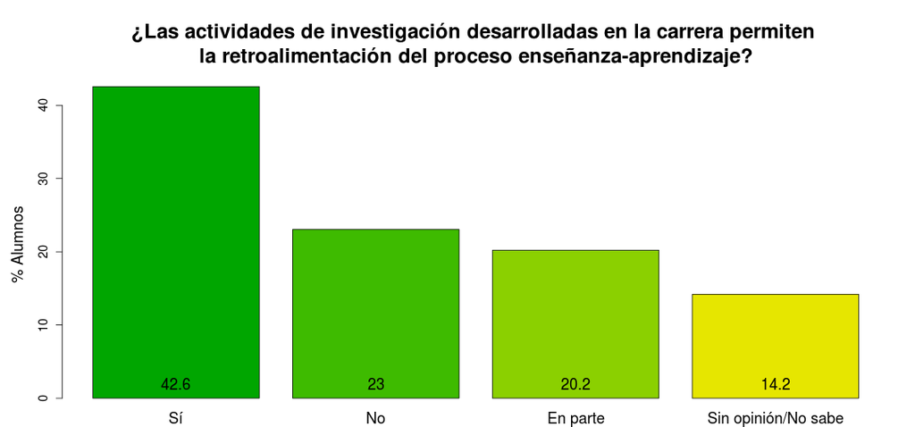

```r
Q.plots(data.alumnos$Q25h, Q25h)
```

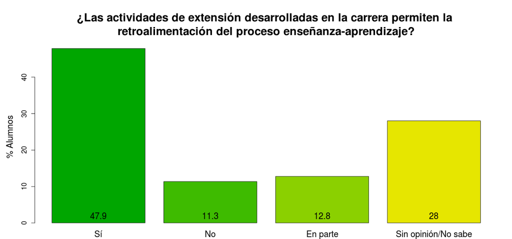

```r
Q.plots(data.alumnos$Q25i, Q25i)
```

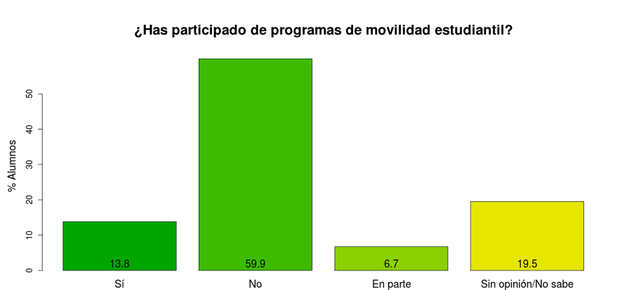

```r
Q.plots(data.alumnos$Q25j, Q25j)
```

### Dimensión 3.1 - Directivos

Los resultados de esta dimensión son los siguientes:

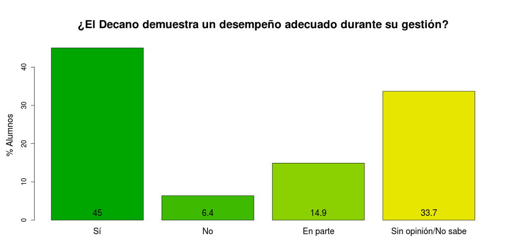

```r
Q.plots(data.alumnos$Q31a, Q31a)
```

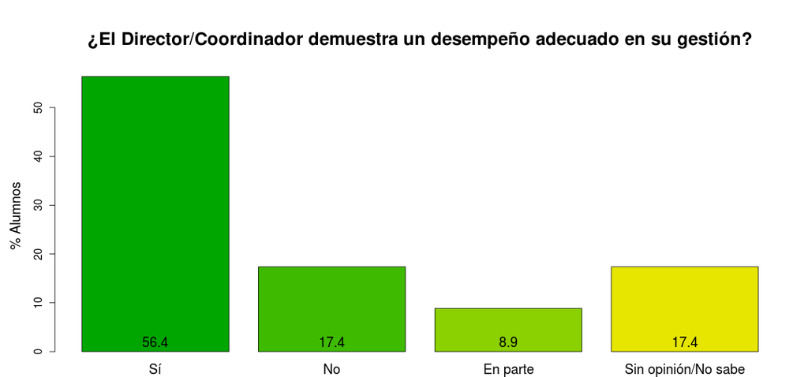

```r
Q.plots(data.alumnos$Q31b, Q31b)
```

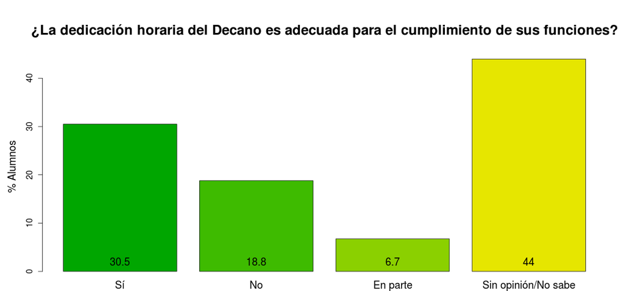

```r
Q.plots(data.alumnos$Q31c, Q31c)
```

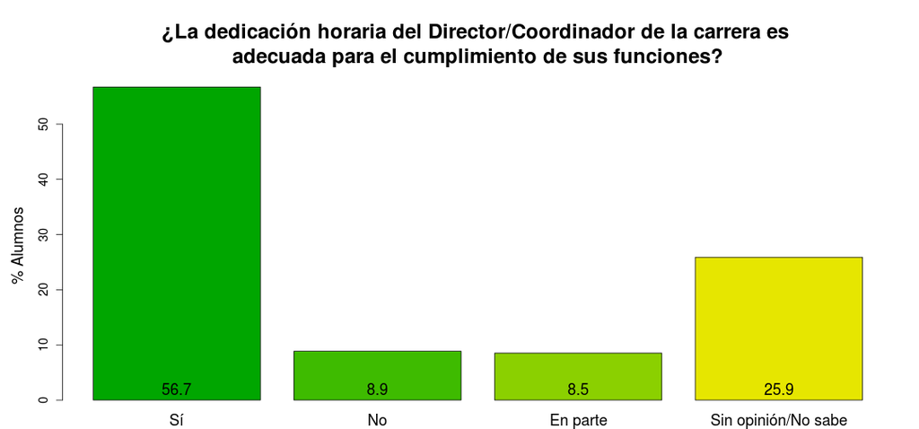

```r
Q.plots(data.alumnos$Q31d, Q31d)
```

### Dimensión 3.2 - Docentes

Los resultados de esta dimensión son los siguientes:

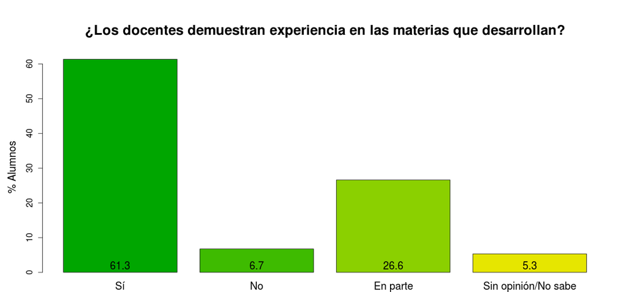

```r
Q.plots(data.alumnos$Q32a, Q32a)
```

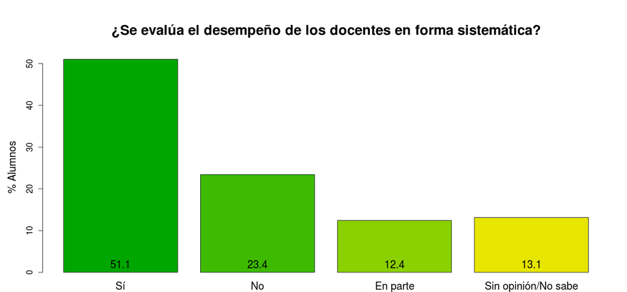

```r
Q.plots(data.alumnos$Q32b, Q32b)
```

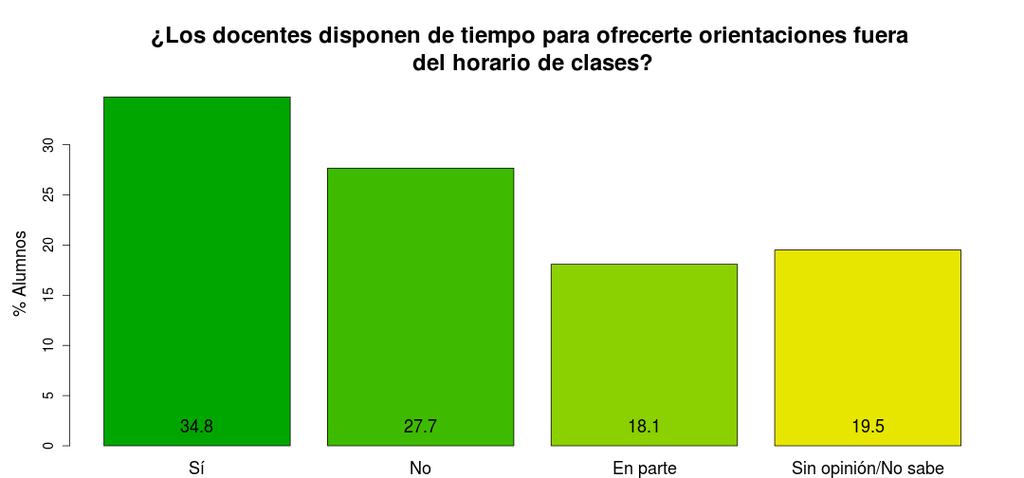

```r
Q.plots(data.alumnos$Q32c, Q32c)
```

### Dimensión 3.3 - Estudiantes

Los resultados de esta dimensión son los siguientes:

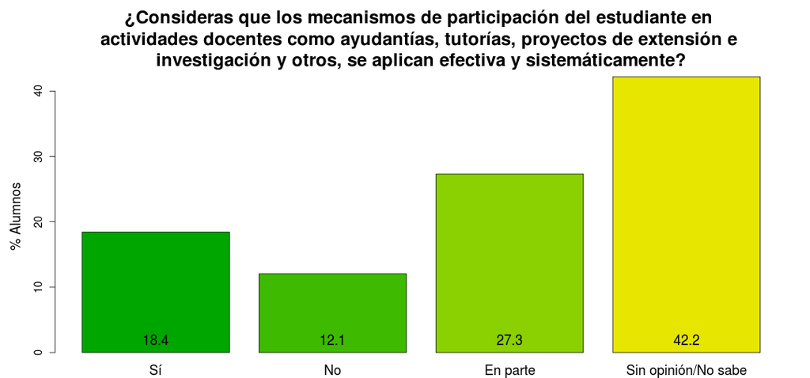

```r
Q.plots(data.alumnos$Q33a, Q33a)
```

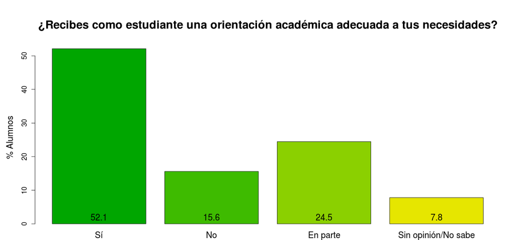

```r
Q.plots(data.alumnos$Q33b, Q33b)
```

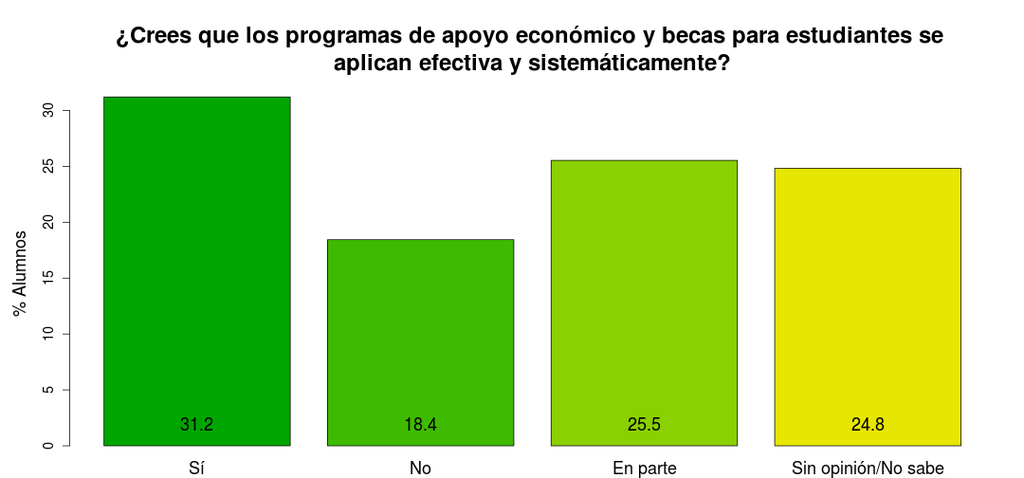

```r
Q.plots(data.alumnos$Q33c, Q33c)
```

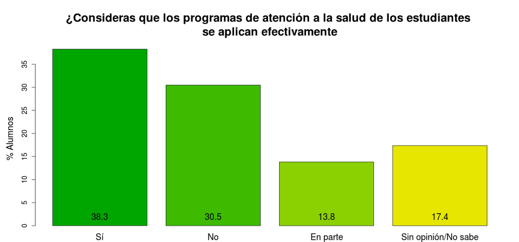

```r
Q.plots(data.alumnos$Q33d, Q33d)
```

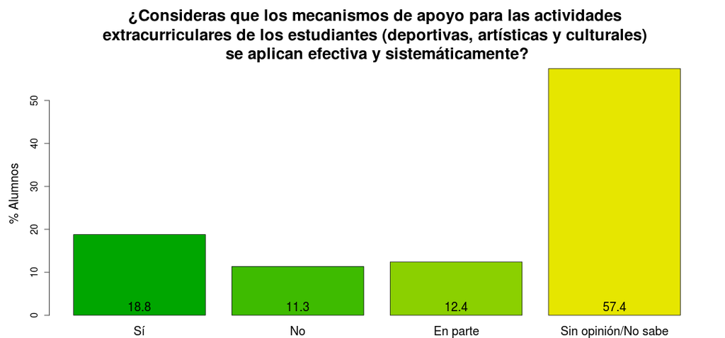

```r
Q.plots(data.alumnos$Q33e, Q33e)
```

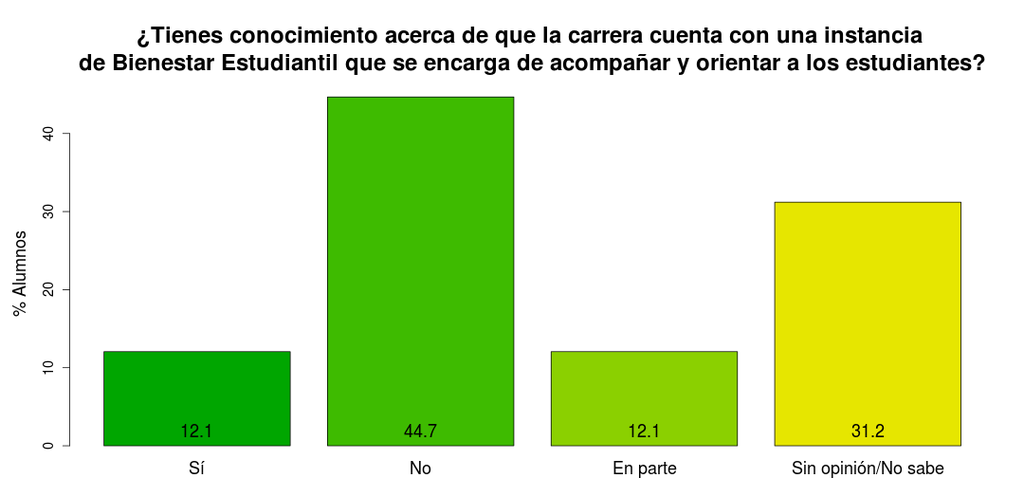

```r
Q.plots(data.alumnos$Q33f, Q33f)
```

### Dimensión 3.4 - Personal administrativo y de apoyo

Los resultados de esta dimensión son los siguientes:

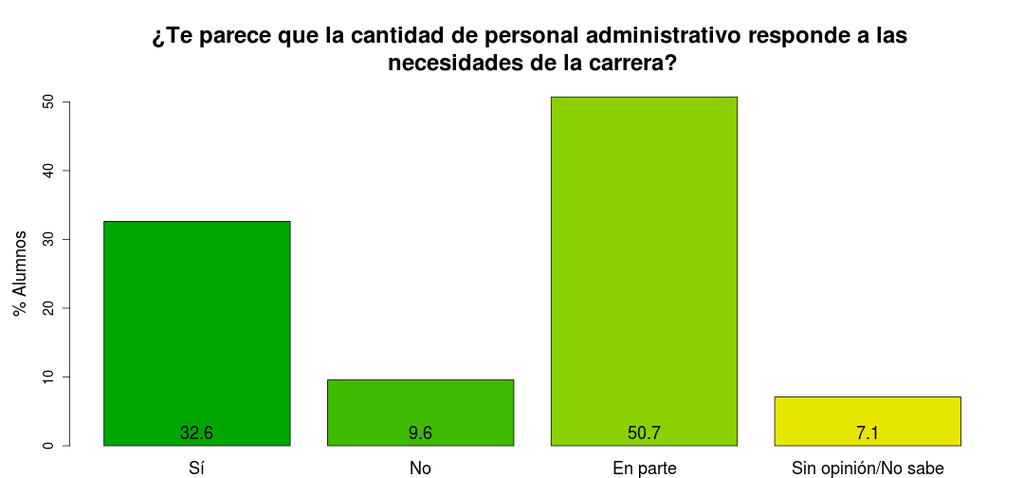

```r
Q.plots(data.alumnos$Q34a, Q34a)
```

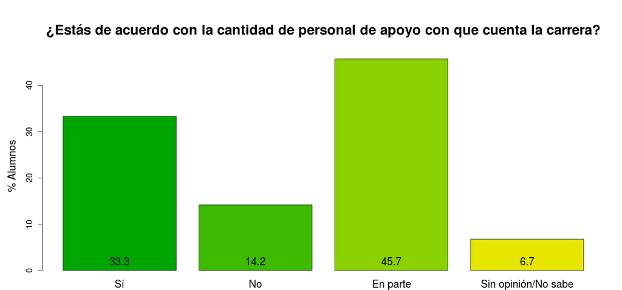

```r
Q.plots(data.alumnos$Q34b, Q34b)
```

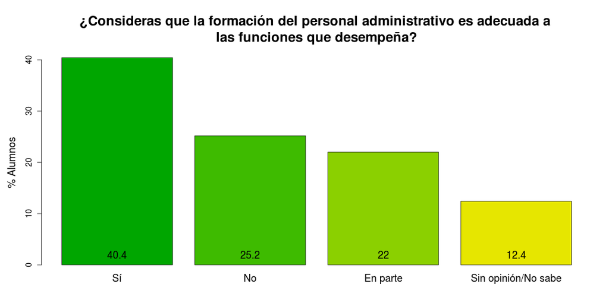

```r
Q.plots(data.alumnos$Q34c, Q34c)
```

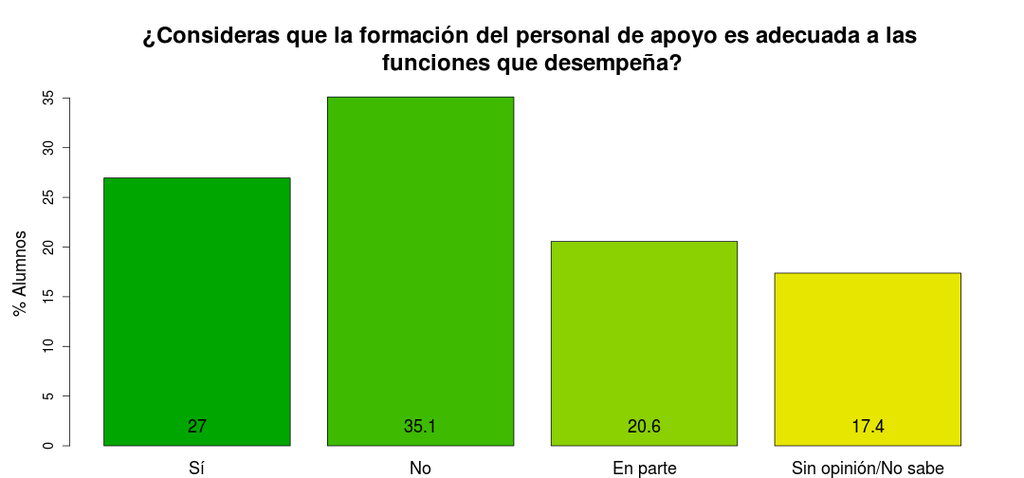

```r
Q.plots(data.alumnos$Q34d, Q34d)
```

### Dimensión 4.1 - Infraestructura, equipamientos e insumos

Los resultados de esta dimensión son los siguientes:

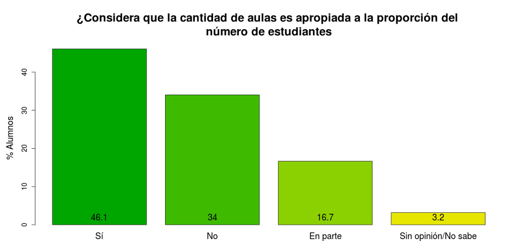

```r
Q.plots(data.alumnos$Q41a, Q41a)
```

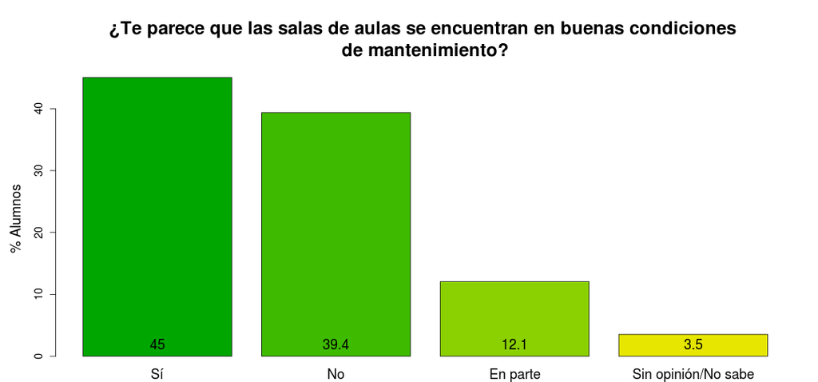

```r
Q.plots(data.alumnos$Q41b, Q41b)
```

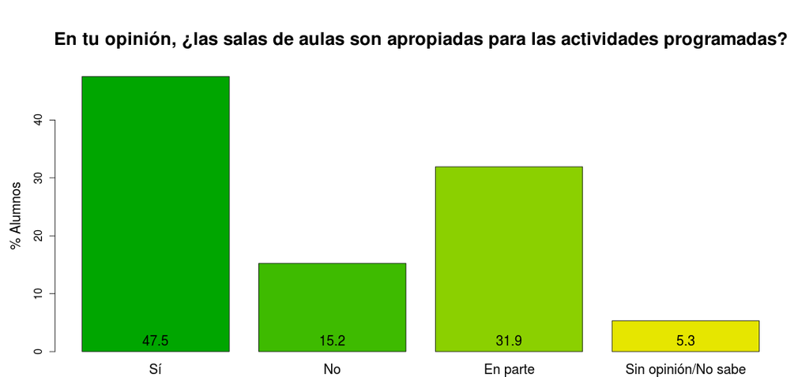

```r
Q.plots(data.alumnos$Q41c, Q41c)
```

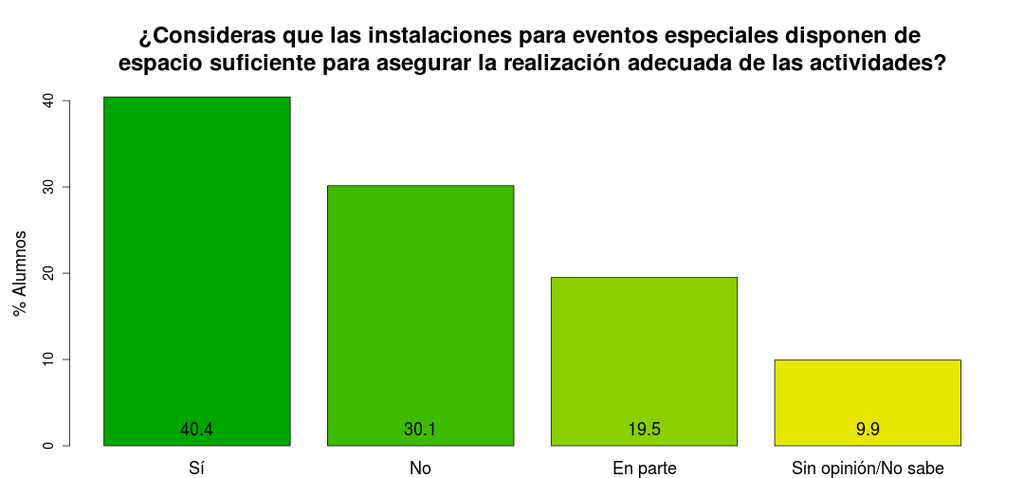

```r
Q.plots(data.alumnos$Q41d, Q41d)
```

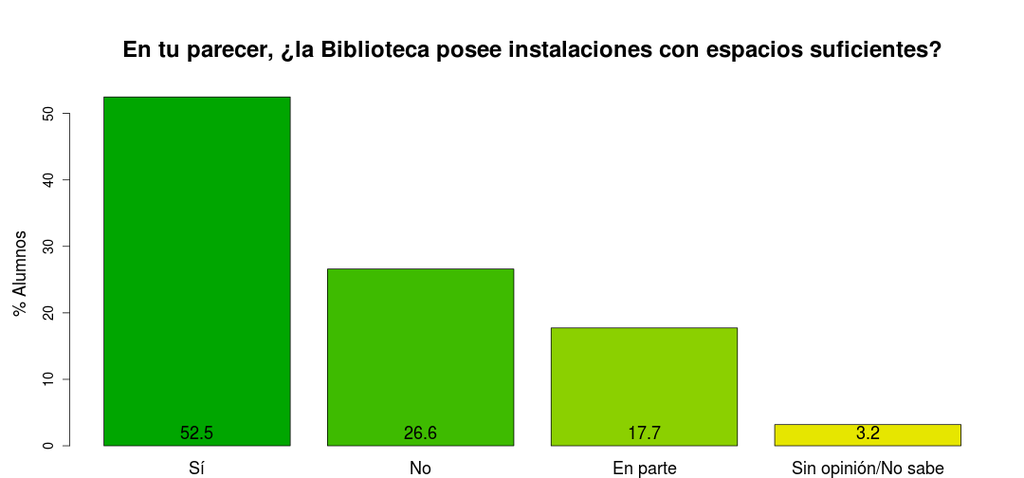

```r
Q.plots(data.alumnos$Q41e, Q41e)
```

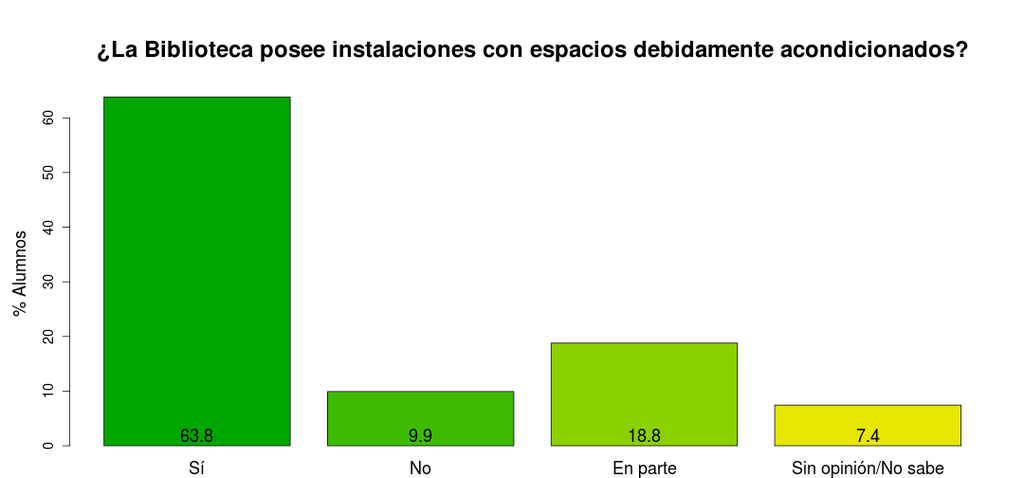

```r
Q.plots(data.alumnos$Q41f, Q41f)
```

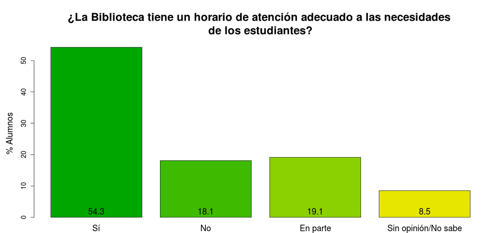

```r
Q.plots(data.alumnos$Q41g, Q41g)
```

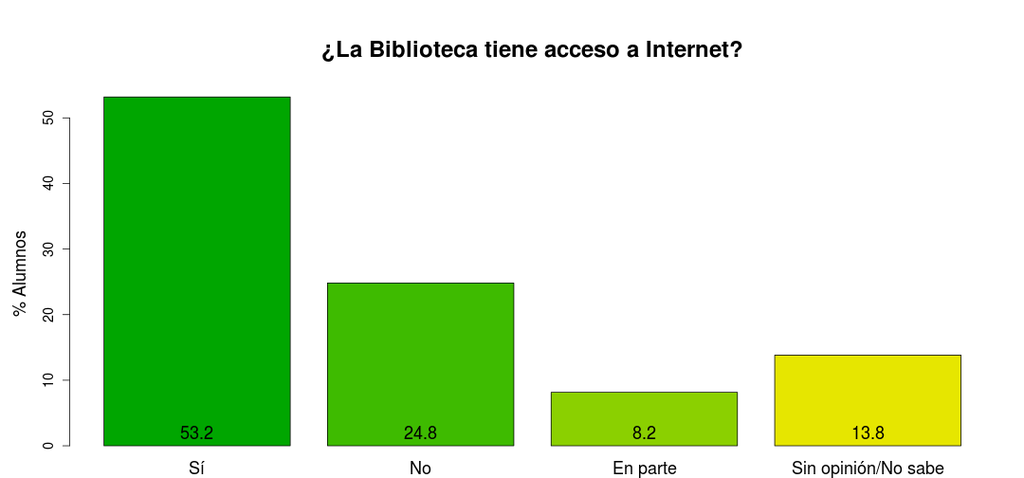

```r
Q.plots(data.alumnos$Q41h, Q41h)
```

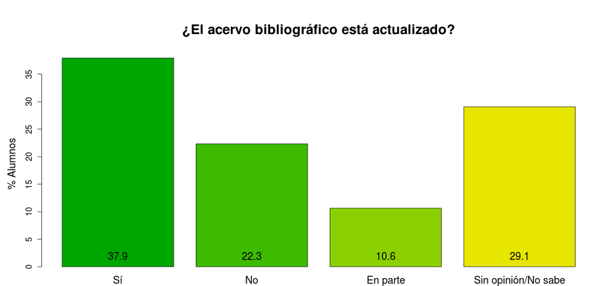

```r
Q.plots(data.alumnos$Q41i, Q41i)
```

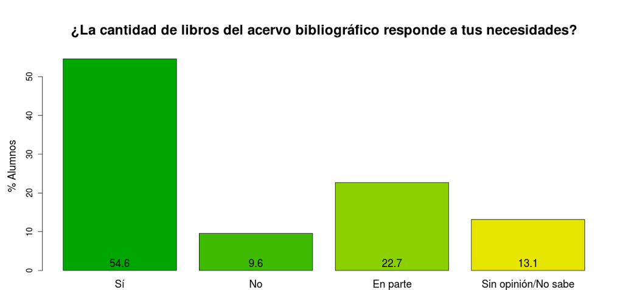

```r
Q.plots(data.alumnos$Q41j, Q41j)
```

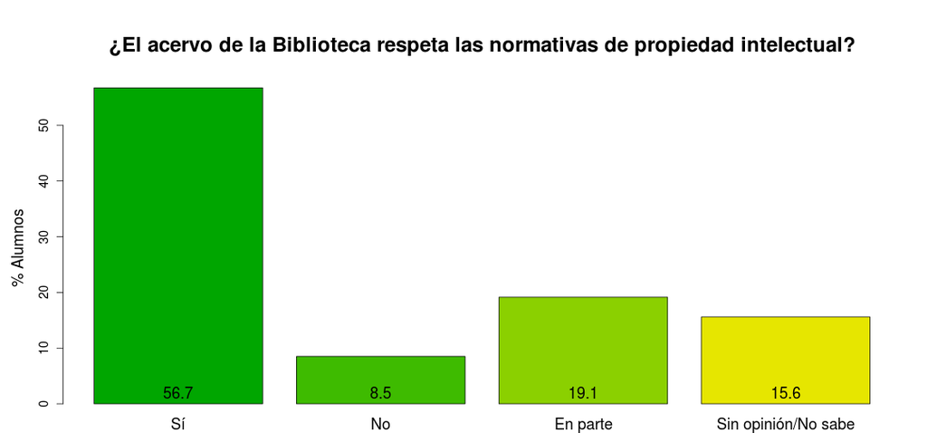

```r
Q.plots(data.alumnos$Q41k, Q41k)
```

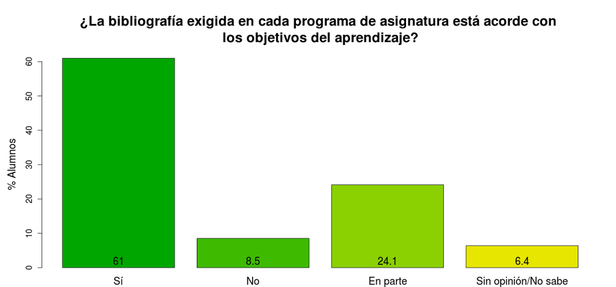

```r
Q.plots(data.alumnos$Q41l, Q41l)
```

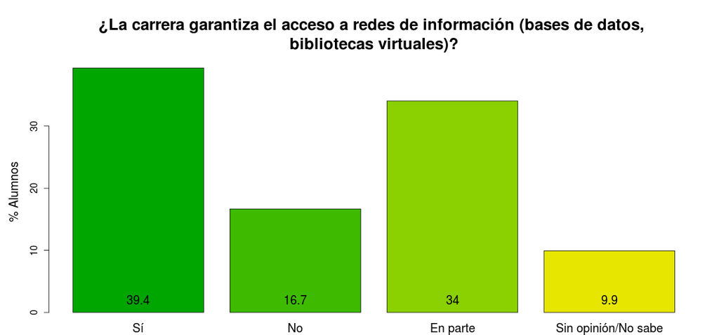

```r
Q.plots(data.alumnos$Q41m, Q41m)
```

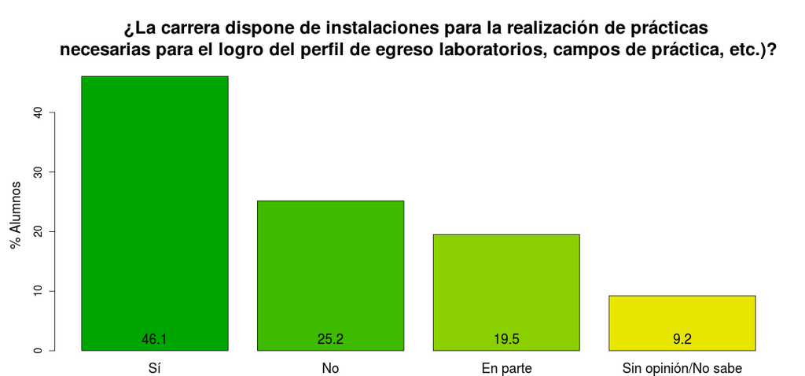

```r
Q.plots(data.alumnos$Q41n, Q41n)
```

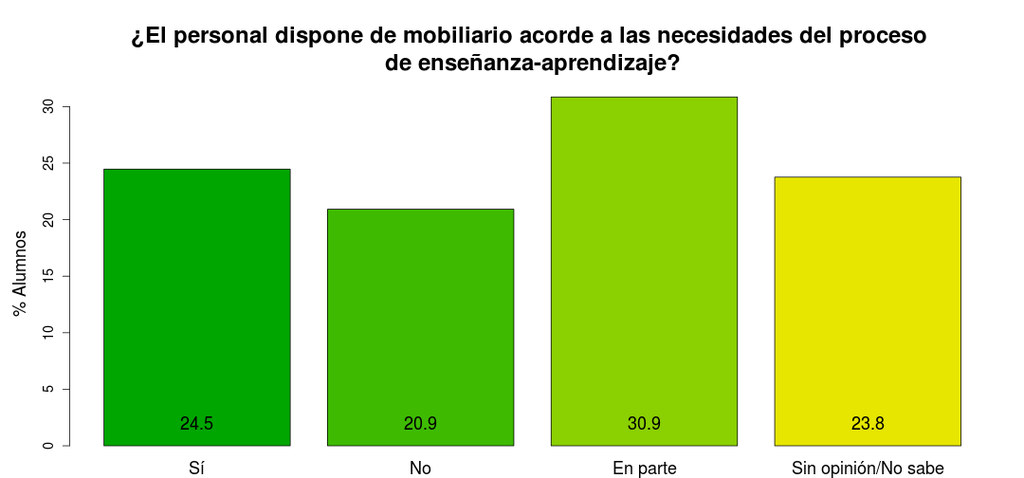

```r
Q.plots(data.alumnos$Q41o, Q41o)
```

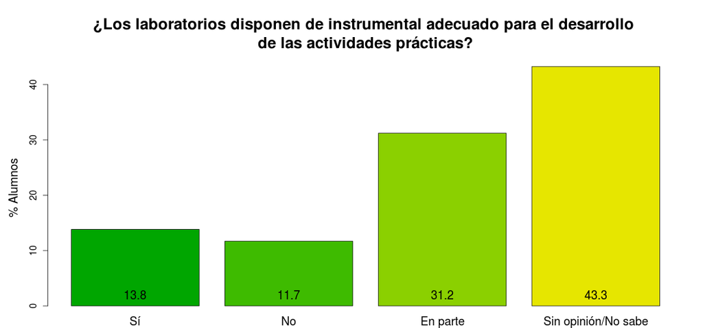

```r
Q.plots(data.alumnos$Q41p, Q41p)
```

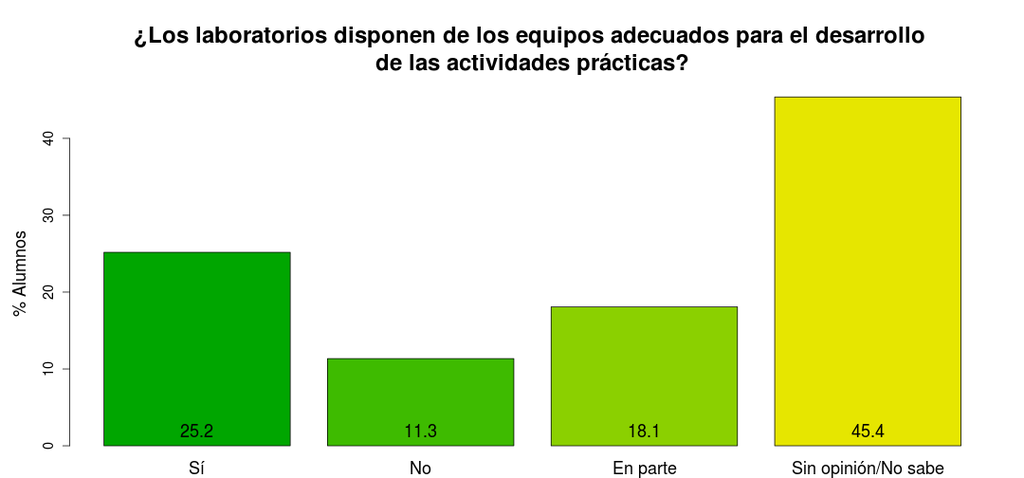

```r
Q.plots(data.alumnos$Q41q, Q41q)
```